# Statistical Graphics and Communication

Stefany Coxe

October 31, 2019

# Adding a specific equation to a plot

## geom_smooth option: add a specific equation to plot

We have used `geom_smooth` before to create a general line

- `method = lm` for a straight line
- `method = loess` for a weighted average smooth line

What if you have a more specific equation?

- This example will use a model-based equation
- But you can also specify a certain (e.g., theoretical) equation

## geom_smooth option: add a specific equation to plot

Remember that we had a not-quite-linear relationship between HS GPA and college GPA

```r
data(FirstYearGPA)
scatter <- ggplot(data = FirstYearGPA,
                      aes(x = HSGPA, y = GPA)) +
  geom_point()
```

## geom_smooth option: add a specific equation to plot

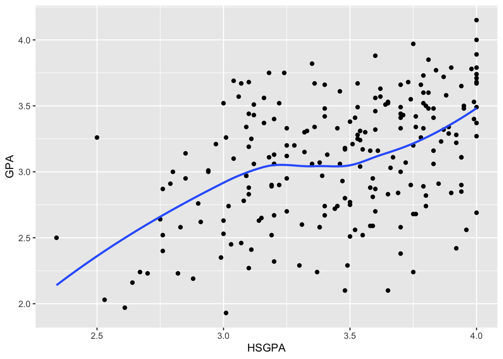

```r
scatter + geom_smooth(method = loess, se = FALSE)
```

## geom_smooth option: add a specific equation to plot

Step 1. Run the model

```r
cubic_model <- lm(GPA ~ HSGPA + I(HSGPA^2) + I(HSGPA^3),
                  data = FirstYearGPA)
cubic_model
```

```
##
## Call:
## lm(formula = GPA ~ HSGPA + I(HSGPA^2) + I(HSGPA^3), data = FirstYearGPA)
##
## Coefficients:
## (Intercept)        HSGPA   I(HSGPA^2)   I(HSGPA^3)
##    -23.9927      23.6388      -6.9833       0.6974
```

## geom_smooth option: add a specific equation to plot

Step 2. Tidy the model

```r
cubic_tidy <- tidy(cubic_model)

print(cubic_tidy)
```

```
## # A tibble: 4 × 5
##   term        estimate std.error statistic p.value
##   <chr>          <dbl>     <dbl>     <dbl>   <dbl>
## 1 (Intercept)  -24.0      13.6       -1.76  0.0793
## 2 HSGPA         23.6      12.6        1.88  0.0613
## 3 I(HSGPA^2)    -6.98      3.84      -1.82  0.0702
## 4 I(HSGPA^3)     0.697     0.388      1.80  0.0734
```

## geom_smooth option: add a specific equation to plot

Step 3 - version 1. Use formula in geom_smooth

```r
cubic_plot1 <- scatter +
  geom_point() +
  geom_smooth(method = lm,
              formula = y ~ x + I(x^2) + I(x^3),
              se = FALSE)
```

## geom_smooth option: add a specific equation to plot

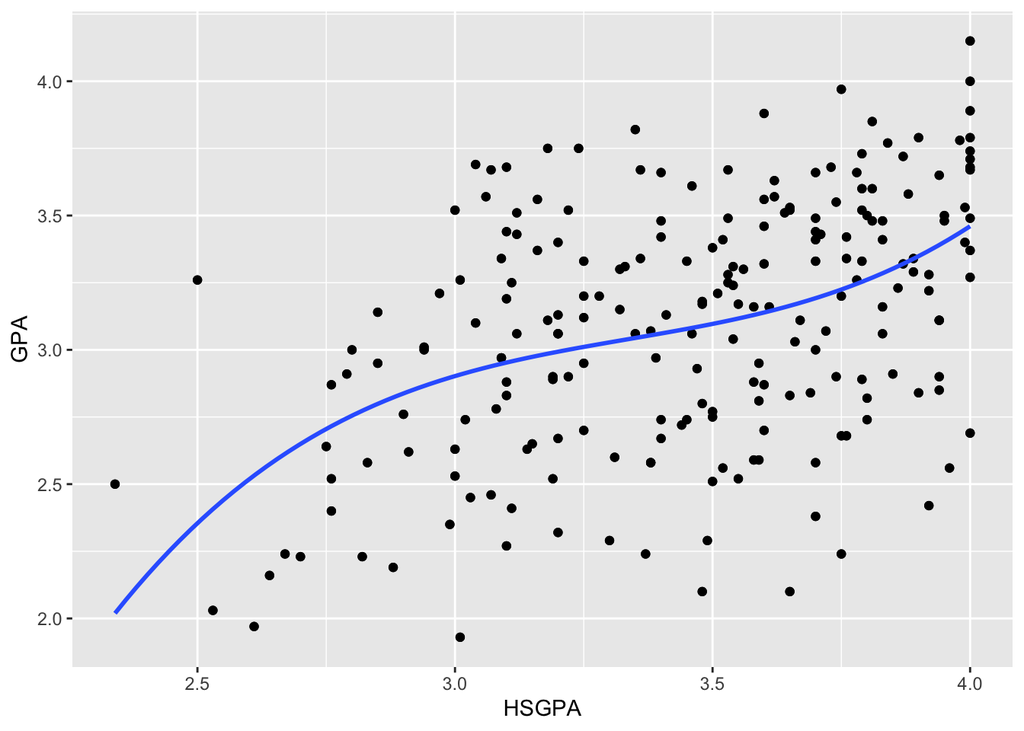

```r
cubic_plot1
```

## geom_smooth option: add a specific equation to plot

Step 3 - version 2. Use model values in geom_smooth

```r
cubic_plot2 <- scatter +
  geom_point() +
  geom_smooth(method = nls,
formula = y ~ intercept + linear*x +
                quadratic*x*x + cubic*x*x*x,
se = FALSE,
method.args = list(start =
c(intercept = cubic_tidy$estimate[1],
linear = cubic_tidy$estimate[2],
quadratic = cubic_tidy$estimate[3],
cubic = cubic_tidy$estimate[4])))
```

## geom_smooth option: add a specific equation to plot

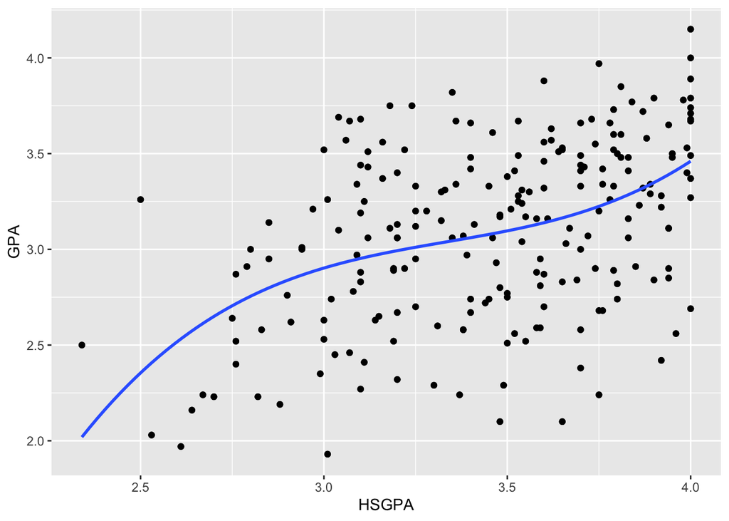

```r
cubic_plot2
```

# Two lines with a legend

## Add another line with a legend

This is a bit of a cheat to get this to work

You take advantage of the fact that

- Color arguments generally go **outside** of `aes()` in a `geom_smooth`
- But if you put the color argument **inside** `aes()`, it treats it as a **label** instead of a color assignment

## Add another line with a legend

```r
model_colors <- RColorBrewer::brewer.pal(3, "Set1")
cubic_plot3 <- scatter + geom_point() +
  geom_smooth(method = nls, se = FALSE,
formula = y ~ intercept + linear*x +
  quadratic*x*x + cubic*x*x*x,
method.args = list(start =
c(intercept = cubic_tidy$estimate[1],
linear = cubic_tidy$estimate[2],
quadratic = cubic_tidy$estimate[3],
cubic = cubic_tidy$estimate[4])),
aes(color = "Cubic", fill = "Cubic")) +
  geom_smooth(method = lm, aes(color = "Linear",
                               fill = "Linear"),
              se = FALSE) +
  scale_color_manual(name = "Models",
                     values = model_colors) +
  scale_fill_manual(name = "Models",
                    values = model_colors)
```

## Add another line with a legend

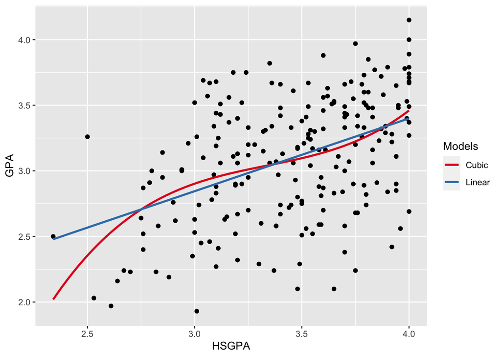

```r
cubic_plot3
```

# Confidence intervals based on your model

## Add CIs to the line

Calculate the confidence intervals based on your model with the `predict` function

- `fit`: predicted value
- `lwr`: lower CI limit
- `upr`: upper CI limit

## Add CIs to the line

```r
gpa_cubic_predictions <- predict(object = cubic_model,
                                 newdata = FirstYearGPA,
                                 interval = "predict")
head(gpa_cubic_predictions)
```

```
##        fit      lwr      upr
## 1 3.285010 2.460852 4.109168
## 2 3.460149 2.624765 4.295534
## 3 3.192314 2.368201 4.016426
## 4 3.100341 2.276226 3.924456
## 5 3.285010 2.460852 4.109168
## 6 3.010882 2.187038 3.834726
```

```r
gpa_cubic_predict <- cbind(FirstYearGPA,
                           gpa_cubic_predictions)
```

## Add CIs to the line

`geom_ribbon` shows a ribbon of color from `ymin` to `ymax`

```r
cubic_plot4 <- scatter + geom_point() +
  geom_line(data = gpa_cubic_predict,
            aes(x = HSGPA, y = fit)) +
  geom_ribbon(data = gpa_cubic_predict,
              aes(ymin = lwr, ymax = upr),
              alpha = .2)
```

## Add CIs to the line

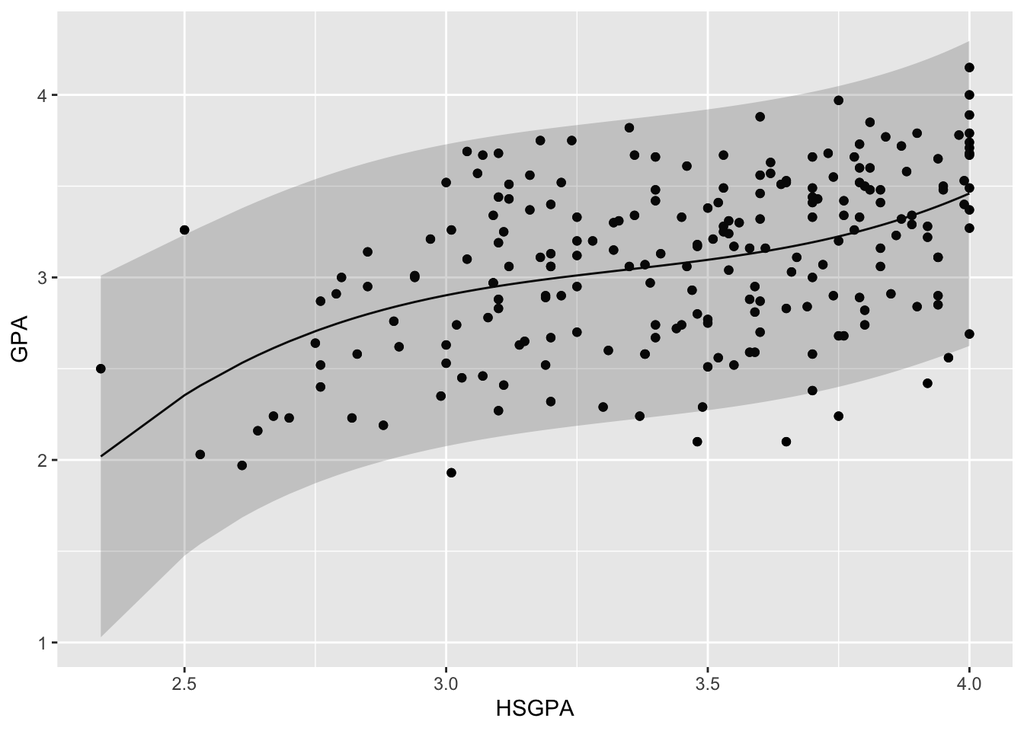

```r
cubic_plot4
```

# nest() and group_by()

## Using nest() and group_by()

We have already used `group_by()` to perform an operation across several groups

- e.g., calculate the mean GDP per capita *for each country*
- One value of mean GDP per capita for each country

The `nest()` function goes one step further and actually splits the dataset up into chunks for each group

- You end up with a **nested table**
- You can run separate analyses and get *separate results*

## Using nest() and group_by()

```r
GPA_nest_genderrace <- FirstYearGPA %>%
  group_by(Male, White) %>%
  nest()
```

## Using nest() and group_by()

```r
GPA_nest_genderrace
```

```
## # A tibble: 4 × 3
## # Groups:   Male, White [4]
##    Male White data
##   <int> <int> <list>
## 1     1     1 <tibble [84 × 8]>
## 2     0     1 <tibble [89 × 8]>
## 3     0     0 <tibble [28 × 8]>
## 4     1     0 <tibble [18 × 8]>
```

## A quick diversion: writing a function

We **use** functions all the time when using R

- `lm()` is a function, `ggplot()` is a function, etc.

We can also **write** functions to do things

- Useful when you’d have to write the same code over and over
- Just call the function instead

## A quick diversion: writing a function

`name_of_fxn <- function(input_args){`

`calculations_and_other_stuff`

`}`

**General structure of a function**

`input_args` are things you might give the function

- They are optional

`calculations_and_other_stuff` are whatever calculations you perform (mathematical operations, models, graphics, etc.)

The function returns the last thing it calculated, or you can tell it to return a specific thing by using

`return(thing_i_want_returned)`

## A quick diversion: writing a function

This function has one argument, `dataframe`

The function uses the specified dataset to run the regression of HSGPA predicing GPA

```r
lm_fxn <- function(dataframe){

lm(GPA ~ HSGPA, data = dataframe)

}
```

## Using nest() and group_by()

The `map()` function applies a *function* to a set of *objects*

`data` is the name of the column in our nested dataframe that contains the actual data

`lm_fxn` is the function we just created

- This will run the regression specified in `lm_fxn` to each of the nested dataframes in the nested dataset
- We will have 4 separate outputs, one for each group

```r
grouped_lm <- GPA_nest_genderrace %>%
  mutate(model = map(data, lm_fxn))
```

## Using nest() and group_by()

Here is the nested dataframe

- One column contains the data for each group
- One column contains the regression model for each group

```r
grouped_lm
```

```
## # A tibble: 4 × 4
## # Groups:   Male, White [4]
##    Male White data              model
##   <int> <int> <list>            <list>
## 1     1     1 <tibble [84 × 8]> <lm>
## 2     0     1 <tibble [89 × 8]> <lm>
## 3     0     0 <tibble [28 × 8]> <lm>
## 4     1     0 <tibble [18 × 8]> <lm>
```

## Using nest() and group_by()

We can apply the `tidy()` function to the nested dataframe

- Again, using the `map()` function

```r
tidy_grouped_lm <- grouped_lm %>%
  mutate(tidied = map(model, tidy))
tidy_grouped_lm
```

```
## # A tibble: 4 × 5
## # Groups:   Male, White [4]
##    Male White data              model  tidied
##   <int> <int> <list>            <list> <list>
## 1     1     1 <tibble [84 × 8]> <lm>   <tibble [2 × 5]>
## 2     0     1 <tibble [89 × 8]> <lm>   <tibble [2 × 5]>
## 3     0     0 <tibble [28 × 8]> <lm>   <tibble [2 × 5]>
## 4     1     0 <tibble [18 × 8]> <lm>   <tibble [2 × 5]>
```

## Using nest() and group_by()

Then we can `unnest()` the dataframe to see values

```r
out_tidy <- tidy_grouped_lm %>%
  unnest(tidied)
out_tidy
```

```
## # A tibble: 8 × 9
## # Groups:   Male, White [4]
##    Male White data              model term  estimate std.error statistic p.value
##   <int> <int> <list>            <lis> <chr>    <dbl>     <dbl>     <dbl>   <dbl>
## 1     1     1 <tibble [84 × 8]> <lm>  (Int…    1.93      0.421     4.60  1.53e-5
## 2     1     1 <tibble [84 × 8]> <lm>  HSGPA    0.366     0.122     3.00  3.60e-3
## 3     0     1 <tibble [89 × 8]> <lm>  (Int…    1.14      0.390     2.93  4.33e-3
## 4     0     1 <tibble [89 × 8]> <lm>  HSGPA    0.571     0.111     5.14  1.69e-6
## 5     0     0 <tibble [28 × 8]> <lm>  (Int…   -0.150     0.521    -0.288 7.76e-1
## 6     0     0 <tibble [28 × 8]> <lm>  HSGPA    0.873     0.150     5.83  3.82e-6
## 7     1     0 <tibble [18 × 8]> <lm>  (Int…    0.875     1.09      0.805 4.32e-1
## 8     1     0 <tibble [18 × 8]> <lm>  HSGPA    0.574     0.321     1.79  9.26e-2
```

## Then filter the dataset

The dataframe includes all the coefficients

- Here, just intercept and slope
- But say that we really only want to look at slope

```r
slopes_only <- out_tidy %>%
  filter(term == "HSGPA")
slopes_only
```

```
## # A tibble: 4 × 9
## # Groups:   Male, White [4]
##    Male White data              model term  estimate std.error statistic p.value
##   <int> <int> <list>            <lis> <chr>    <dbl>     <dbl>     <dbl>   <dbl>
## 1     1     1 <tibble [84 × 8]> <lm>  HSGPA    0.366     0.122      3.00 3.60e-3
## 2     0     1 <tibble [89 × 8]> <lm>  HSGPA    0.571     0.111      5.14 1.69e-6
## 3     0     0 <tibble [28 × 8]> <lm>  HSGPA    0.873     0.150      5.83 3.82e-6
## 4     1     0 <tibble [18 × 8]> <lm>  HSGPA    0.574     0.321      1.79 9.26e-2
```

## Then make a plot of the values

```r
est_grouped <- ggplot(data = slopes_only,
            mapping = aes(x = as.factor(Male), y = estimate,
                          ymin = estimate - 2*std.error,
                          ymax = estimate + 2*std.error,
                          group = as.factor(White), color = as.factor(White))) +
  geom_errorbar(position = position_dodge(width = 1)) +
  labs(x = "Gender", y = "Estimate", color = "Race")
```

## Then make a plot of the values

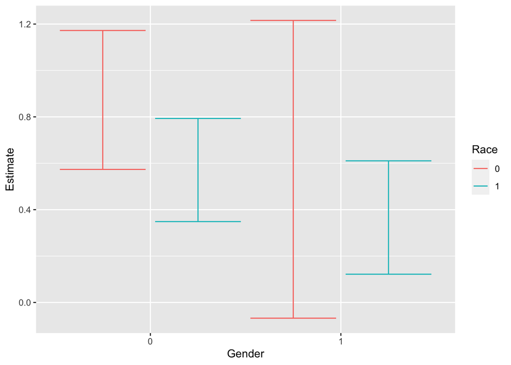

```r
est_grouped
```

# Interactivity overview

## Interactivity – what is it?

There are many types of interactivity

- Filter data based on a variable
- Zoom in on a plot
- Add fit lines of various types

Anything that changes your plot from static

## Interactivity – how can I do it?

The very simplest way to introduce interactivity is with a package called **plotly**

Wrap your ggplot (or any other plot) in the `ggplotly()` function:

`ggplotly(scatter)`

(This only works for HTML output, so I’m not running it here – see **plotlyHTMLdemo** file)

You can select certain portions of the plot, zoom in, mouse over to see data values, etc.

- But it also *doesn’t require any connection to R* to work

## More ways to introduce interactivity

From least to most flexible / interactive:

- **flexdashboard** package
- **shinydashboard** package
- **shiny** elements in a **markdown** file
- stand-alone **shiny** app

## **flexdashboard**

https://rmarkdown.rstudio.com/flexdashboard/

Done through a **markdown** document

- After installing **flexdashboard**, there is a template available for your **markdown** document

Focus is on the layout and static objects

See **flexdashboarddemo** file for an example

## **shinydashboard**

https://rstudio.github.io/shinydashboard/get_started.html

Done through a (non-**markdown**) R syntax file

Two functions contain most of your code: `ui` and `server`

- `ui` contains information about the look, including input and output objects
- `server` constains information about any calculations or graphics

At the end, run `shinyApp(ui, server)` to run the app

- Note that it’s no longer “Knit” but “Run”

See **shinydashboarddemo** file for an example

## **shiny** elements in a **markdown** file

https://bookdown.org/yihui/rmarkdown/shiny-documents.html

Done within a **markdown** document, but not to make a whole dashboard (as in **flexdashboard**) but to add a small interactive element to a **markdown** document

- Need to specify `runtime: shiny` in the YAML (not indented, so it’s a top-level option)
- Note that it’s no longer “Knit” but “Run”

See **shinyinmarkdowndemo** file for an example

## Stand-alone **shiny** app

Start by selecting “New File” and then “Shiny Web App”

- You can choose a single file or multiple file format
  - Single file: 1 file called “app.R” in a folder with the name of your application
  - Multiple file: 1 file called “ui.R” with the UI code and 1 file called “server.R” with the calculations code
- Single file can be easier because it’s all in one place, but multiple file is easier to deal with for large projects

The template is already in place, just fill in your input, output, and calculations code

See **app.R** file for an example

- Put it in a folder called “shiny_demo”, open it in R, and run it

## Shiny input functions

There are a bunch of pre-defined input widgets (functions)

`numericInput`

`radioButtons`

`sliderInput`

`fileInput`

With a few exceptions, they end with “Input”

See http://shiny.rstudio.com/tutorial/written-tutorial/lesson3/ for a full list with examples

Each one requires at least 1) a label that you’ll use to refer to it in the program and 2) a text label that will show up in the app

- Some widgets have other options too

## Shiny output functions

Output functions are actually pairs of functions

- One defines the object you’re outputting (in `server.R` if you have one)
  - These usually start with “render” such as `renderPlot` or `renderTable`
  - Your code (e.g., a call to a named `ggplot`) will go inside
- One defines where to put the object (in the `ui.R` if you have one)
  - These will match the render functions, such as `plotOutput` or `tableOutput`
  - Usually, the only argument is the named object from the server

See http://shiny.rstudio.com/tutorial/written-tutorial/lesson4/ for a full list with examples